# Business Statistic Project 2

# Prove (or disprove) with statistical evidence that the BMI of females is different from that of males.

BMI of female is equal to male The researcher will test the null hypothesis

H0 = BMI of females is equals to males

against the alternate hypothesis

Ha ≠ BMI of female is different from that of male

```python
data['sex'].value_counts()
```

```
male      676
female    662
Name: sex, dtype: int64
```

### Create a new DataFrame to seperate the male from female in relations to BMI the dataset

```python
male_BMI=data["bmi"][data["sex"]=="male"]
female_BMI=data["bmi"][data["sex"]=="female"]
```

### Calculate the mean and standard deviation for BMI and sex to determine the equality

```python
print(male_BMI.mean())
print(female_BMI.mean())
print(male_BMI.std())
print(female_BMI.std())
```

```
30.943128698224832
30.377749244713023
6.140434615792248
6.046023085745338
```

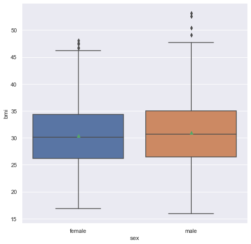

```python
plt.figure(figsize = (8,8))
sns.boxplot(x="sex", y="bmi",
                data=data, showmeans=True)
```

1. Continuous data - Yes, the BMI is measured on a continuous scale.
2. Independent populations - As we are taking random samples for two different type of users, the two samples are from two independent populations.
3. Equal population standard deviations - The sample standard deviations are equal.
4. Random sampling from the population - The collected sample is a simple random sample.

# P-Value of Hypothsis

```python
from scipy.stats import ttest_ind


test_stat, p_value = ttest_ind(male_BMI,female_BMI, equal_var = True, alternative = 'two-sided')

print('The p-value is ' + str(p_value))
```

```
The p-value is 0.08997637178984932
```

## Discovery

As the p-value(~0.089976) is much greater than the level of significance, I fail to reject the null hypothesis. Hence, we do not have enough significance to conclude that the BMI of females is different from that of males.¶ at 0.05 significance level.

## Is the proportion of smokers significantly different across different regions? [Hint : Create a contingency table/cross tab, Use the function : stats.chi2_contingency()]

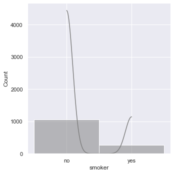

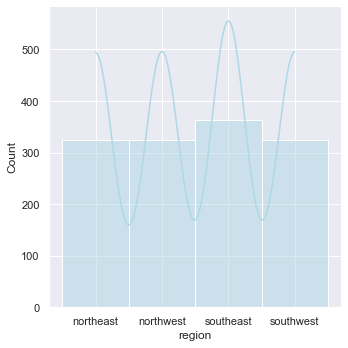

```python
sns.displot(data["smoker"],color="grey", kde = True)
sns.displot(data["region"],color="lightblue", kde = True)
plt.show()
```

```python
data["region"].value_counts(dropna=False)
```

```
southeast    364
southwest    325
northwest    325
northeast    324
Name: region, dtype: int64
```

```python
from scipy.stats import chi2_contingency
```

```python
contigency = pd.crosstab (data['region'], data['smoker'], margins = False)
contigency
```

| smoker region | no | yes |
| --- | --- | --- |
| northeast | 257 | 67 |
| northwest | 267 | 58 |
| southeast | 273 | 91 |
| southwest | 267 | 58 |

### P-Value

```python
c, pval, dof, expected = chi2_contingency(contigency)

print(pval)
if pval < 0.05:
    print(f'As the p-value {pval} is less than the level of significance, we reject the null hypothesis.')
else:
    print(f'As the p-value {pval} is greater than the level of significance, we fail to reject the null hypothesis.')
```

```
0.06171954839170541
As the p-value 0.06171954839170541 is greater than the level of significance, we fail to reject the null hypothesis.
```